# Raport

# 1. Raport z analizy danych z kategorii i w czasie:

[output not shown]

```
## [1] "Wed Dec 19 12:55:00 2018"
```

# 2. Przygotowanie danych

Najpierw zostaĹ‚ przeprowadzony etap czyszczenia danych z wartoĹ›ci bĹ‚Ä™dnych i odrzucaniem punktĂłw oddalonych (wiÄ™kszych niĹĽ 3-krotnoĹ›Ä‡ odchylenia standardowego od wartoĹ›ci Ĺ›redniej). Na poniĹĽszej grafice znajdziemy wykres pokazujÄ…cy te punkty:

## a) dla parametru

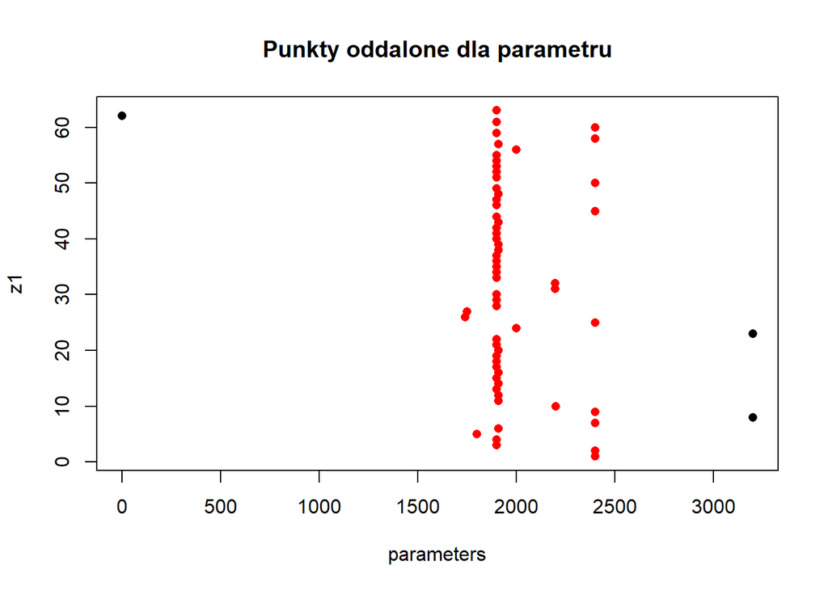

## b) dla ceny

[figure not shown]

# 3. Histogramy, tablice rozkĹ‚adu wystÄ…pieĹ„

## a) dla ceny, przed transformacjÄ…

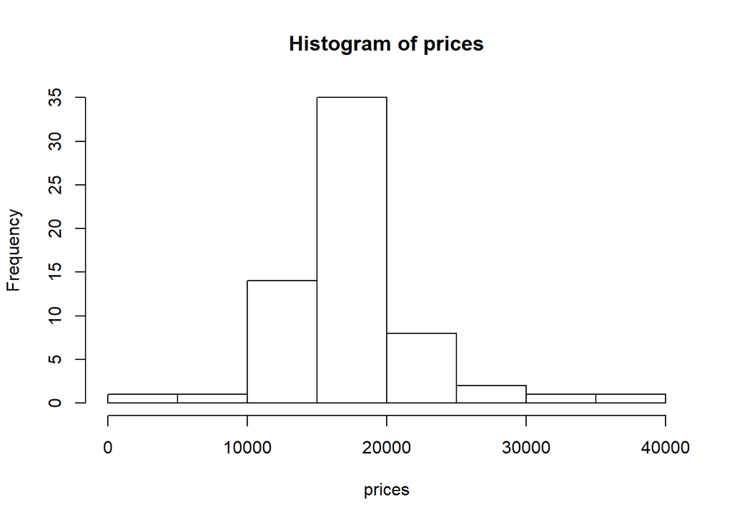

## b) dla ceny, po transformacji

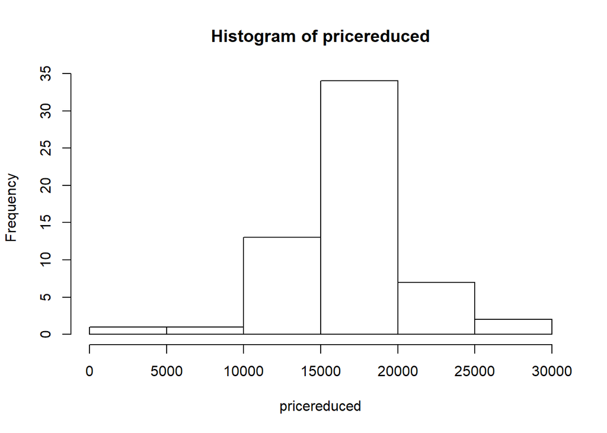

## c) dla parametrĂłw przed transformacjÄ…

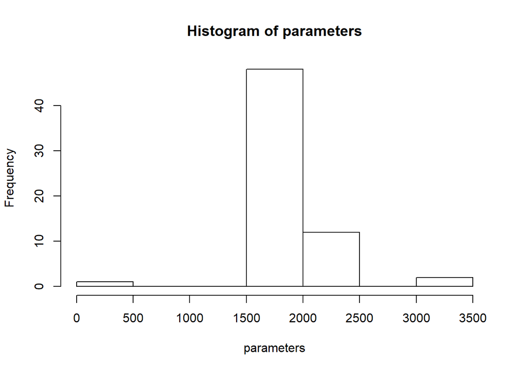

## d) dla parametrĂłw po transformacji

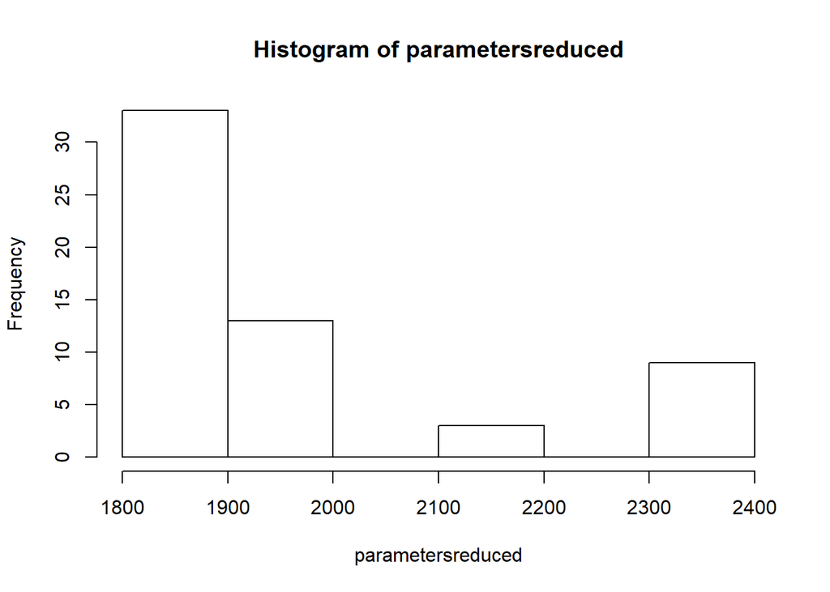

# 4. Grupowanie danych

Grupowanie danych przebiegaĹ‚o za pomocÄ… metody k-Ĺ›rednich, sĹ‚uĹĽy znalezieniu grup potencjalnej konkurencji w sprzedaĹĽy, jak i ogĂłlnemu zarysowaniu rynku i licznoĹ›ci grup.

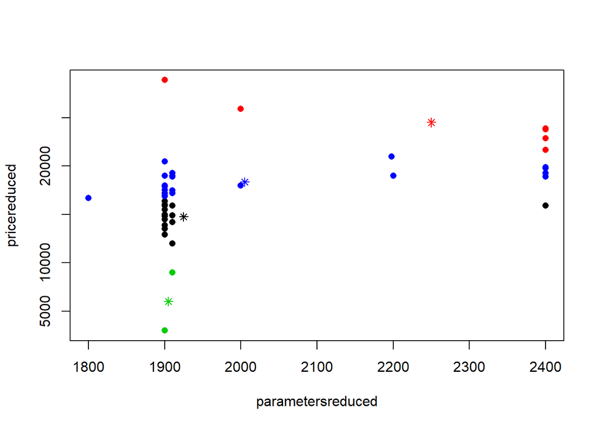

# 5. Selekcja cen potencjalnych

Na poniĹĽszym wykresie znajdziemy rozkĹ‚ad normalny po transformacji oraz zaznaczone punkty, ktĂłre zostaĹ‚y wyliczone jako wartoĹ›ci potencjalnie istotne dla uĹĽytkownika.

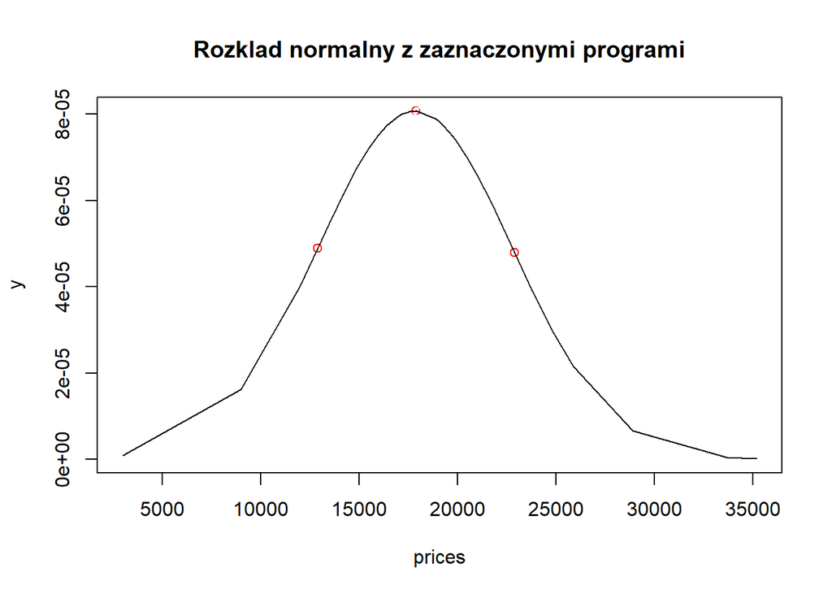

# 6. WartoĹ›ci cen potencjalncych

ZostaĹ‚y wyliczone nastÄ™pujÄ…ce wartoĹ›ci dla cen jako wartoĹ›ci przewidywalne:

### a) WartoĹ›Ä‡ minimalna

```
## [1] 12908.45
```

WartoĹ›Ä‡, dla ktĂłrej przedmiot aukcji sprzeda sie bĹ‚yskawicznie, w tej kategorii cenowej jest najwiÄ™kszy popyt na wybrany rodzaj produktu. WiÄ…ĹĽe siÄ™ to jednak ze stosunkowo maĹ‚ym zarobkiem.

### b) WartoĹ›Ä‡ potencjalnie najlepsza

```
## [1] 17855.49
```

Jest to wartoĹ›Ä‡, ktĂłra gwarantuje sprzedaĹĽ produktu, nie w czasie bĹ‚yskawicznym, ale po odczekaniu pewnej chwili oraz posiada wiÄ™kszy zysk niĹĽ wartoĹ›Ä‡ pierwsza, jest to wartoĹ›Ä‡ najrozsÄ…dniejsza dla kupca, jeĹĽeli nie zaleĹĽy mu tak bardzo na bĹ‚yskawicznej sprzedaĹĽy, ale chce byÄ‡ pewny ĹĽe przedmiot zostanie przez kogoĹ› kupiony.

### c) WartoĹ›Ä‡ z ryzykiem

```
## [1] 22802.53
```

Po wystawieniu do tej ceny, istnieje jeszcze szansa, ĹĽe nasz produkt siÄ™ sprzeda. Jednak bÄ™dzie to zapewne wiÄ…zaĹ‚o siÄ™ z dĹ‚ugim czasem oczekiwania na sprzedaĹĽ produktu, oraz nie mamy zagwarantowane, ĹĽe tak bÄ™dzie. PowyĹĽej tej kwoty jest bardzo ciÄ™ĹĽko sprzedaÄ‡ produkt.